# Class 14 - Lecture

Hari Subhash

Date created: 2019-04-25

**LEARNING OBJECTIVE** Solidify tidyr

**TOPICS**

1. Recap tidyr
2. Clean the who data (https://www.who.int/tb/country/data/download/en/)

## Revise tidyr syntax

What does gather function do? Gather function gathers up columns into key value pairs.

| country | year | cases | population |
| --- | --- | --- | --- |
| Afghanistan | 1999 | 745 | 19987071 |
| Afghanistan | 2000 | 2666 | 20595360 |
| Brazil | 1999 | 37737 | 172006362 |
| Brazil | 2000 | 80488 | 174504898 |
| China | 1999 | 212258 | 1272915272 |
| China | 2000 | 213766 | 1280428583 |

| country | year | case_pop | val |
| --- | --- | --- | --- |
| Afghanistan | 1999 | cases | 745 |
| Afghanistan | 2000 | cases | 2666 |
| Brazil | 1999 | cases | 37737 |
| Brazil | 2000 | cases | 80488 |
| China | 1999 | cases | 212258 |
| China | 2000 | cases | 213766 |
| Afghanistan | 1999 | population | 19987071 |
| Afghanistan | 2000 | population | 20595360 |
| Brazil | 1999 | population | 172006362 |
| Brazil | 2000 | population | 174504898 |

[output cut: 2 more lines]

Another way to do the same thing is.

| country | year | case_pop | val |
| --- | --- | --- | --- |
| Afghanistan | 1999 | cases | 745 |
| Afghanistan | 2000 | cases | 2666 |
| Brazil | 1999 | cases | 37737 |
| Brazil | 2000 | cases | 80488 |
| China | 1999 | cases | 212258 |
| China | 2000 | cases | 213766 |
| Afghanistan | 1999 | population | 19987071 |
| Afghanistan | 2000 | population | 20595360 |
| Brazil | 1999 | population | 172006362 |
| Brazil | 2000 | population | 174504898 |

[output cut: 2 more lines]

Yet another way to do this.

| country | year | case_pop | val |
| --- | --- | --- | --- |
| Afghanistan | 1999 | cases | 745 |
| Afghanistan | 2000 | cases | 2666 |
| Brazil | 1999 | cases | 37737 |
| Brazil | 2000 | cases | 80488 |
| China | 1999 | cases | 212258 |
| China | 2000 | cases | 213766 |
| Afghanistan | 1999 | population | 19987071 |
| Afghanistan | 2000 | population | 20595360 |
| Brazil | 1999 | population | 172006362 |
| Brazil | 2000 | population | 174504898 |

[output cut: 2 more lines]

## What is tidy data

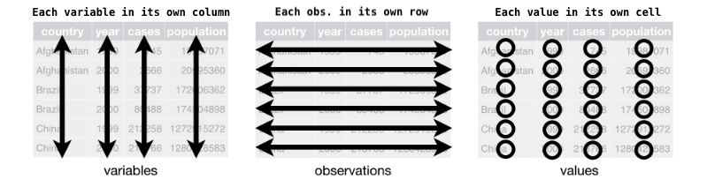

## Spread

| country | year | type | count |
| --- | --- | --- | --- |
| Afghanistan | 1999 | cases | 745 |
| Afghanistan | 1999 | population | 19987071 |
| Afghanistan | 2000 | cases | 2666 |
| Afghanistan | 2000 | population | 20595360 |
| Brazil | 1999 | cases | 37737 |
| Brazil | 1999 | population | 172006362 |
| Brazil | 2000 | cases | 80488 |
| Brazil | 2000 | population | 174504898 |
| China | 1999 | cases | 212258 |
| China | 1999 | population | 1272915272 |

[output cut: 2 more lines]

Spread functions spreads a key value pair into multiple columns.

| country | year | cases | population |
| --- | --- | --- | --- |
| Afghanistan | 1999 | 745 | 19987071 |
| Afghanistan | 2000 | 2666 | 20595360 |
| Brazil | 1999 | 37737 | 172006362 |
| Brazil | 2000 | 80488 | 174504898 |
| China | 1999 | 212258 | 1272915272 |
| China | 2000 | 213766 | 1280428583 |

## Separate

|  | country | year | rate |
| --- | --- | --- | --- |
| 1 | Afghanistan | 1999 | 745/19987071 |
| 2 | Afghanistan | 2000 | 2666/20595360 |
| 3 | Brazil | 1999 | 37737/172006362 |
| 4 | Brazil | 2000 | 80488/174504898 |
| 5 | China | 1999 | 212258/1272915272 |
| 6 | China | 2000 | 213766/1280428583 |

```r
separate(table3, col = rate, into = c("cases", "population"), sep = "/")
```

| country | year | cases | population |
| --- | --- | --- | --- |
| Afghanistan | 1999 | 745 | 19987071 |
| Afghanistan | 2000 | 2666 | 20595360 |
| Brazil | 1999 | 37737 | 172006362 |
| Brazil | 2000 | 80488 | 174504898 |
| China | 1999 | 212258 | 1272915272 |
| China | 2000 | 213766 | 1280428583 |

## unite

|  | country | century | year | rate |
| --- | --- | --- | --- | --- |
| 1 | Afghanistan | 19 | 99 | 745/19987071 |
| 2 | Afghanistan | 20 | 00 | 2666/20595360 |
| 3 | Brazil | 19 | 99 | 37737/172006362 |
| 4 | Brazil | 20 | 00 | 80488/174504898 |
| 5 | China | 19 | 99 | 212258/1272915272 |
| 6 | China | 20 | 00 | 213766/1280428583 |

Unite mirrors separate. It combines specified columns into a new column.

| country | yearNew | rate |
| --- | --- | --- |
| Afghanistan | 19Yo99 | 745/19987071 |
| Afghanistan | 20Yo00 | 2666/20595360 |
| Brazil | 19Yo99 | 37737/172006362 |
| Brazil | 20Yo00 | 80488/174504898 |
| China | 19Yo99 | 212258/1272915272 |
| China | 20Yo00 | 213766/1280428583 |

While it is rarely used, it is handy when doing things like combining entire rows of a tibble into a single value. See below.

| everything |
| --- |
| Afghanistan, 19, 99, 745/19987071 |
| Afghanistan, 20, 00, 2666/20595360 |
| Brazil, 19, 99, 37737/172006362 |
| Brazil, 20, 00, 80488/174504898 |
| China, 19, 99, 212258/1272915272 |
| China, 20, 00, 213766/1280428583 |

## Issues with gapminder_wide

```r
gapminderUntidy <- read_csv("assets/gapminder_wide.csv")
gapminderUntidy
```

| continent | country | gdpPercap_1952 | gdpPercap_1957 | gdpPercap_1962 | gdpPercap_1967 | gdpPercap_1972 | gdpPercap_1977 | gdpPercap_1982 | gdpPercap_1987 | gdpPercap_1992 | gdpPercap_1997 | gdpPercap_2002 | gdpPercap_2007 | lifeExp_1952 | lifeExp_1957 | lifeExp_1962 | lifeExp_1967 | lifeExp_1972 | lifeExp_1977 | lifeExp_1982 | lifeExp_1987 | lifeExp_1992 | lifeExp_1997 | lifeExp_2002 | lifeExp_2007 | pop_1952 | pop_1957 | pop_1962 | pop_1967 | … |
| --- | --- | --- | --- | --- | --- | --- | --- | --- | --- | --- | --- | --- | --- | --- | --- | --- | --- | --- | --- | --- | --- | --- | --- | --- | --- | --- | --- | --- | --- | --- |
| Africa | Algeria | 2449.0082 | 3013.9760 | 2550.8169 | 3246.9918 | 4182.6638 | 4910.4168 | 5745.1602 | 5681.3585 | 5023.2166 | 4797.2951 | 5288.0404 | 6223.3675 | 43.077 | 45.68500 | 48.30300 | 51.40700 | 54.51800 | 58.01400 | 61.368 | 65.799 | 67.744 | 69.152 | 70.994 | 72.301 | 9279525 | 10270856 | 11000948 | 12760499 | … |
| Africa | Angola | 3520.6103 | 3827.9405 | 4269.2767 | 5522.7764 | 5473.2880 | 3008.6474 | 2756.9537 | 2430.2083 | 2627.8457 | 2277.1409 | 2773.2873 | 4797.2313 | 30.015 | 31.99900 | 34.00000 | 35.98500 | 37.92800 | 39.48300 | 39.942 | 39.906 | 40.647 | 40.963 | 41.003 | 42.731 | 4232095 | 4561361 | 4826015 | 5247469 | … |
| Africa | Benin | 1062.7522 | 959.6011 | 949.4991 | 1035.8314 | 1085.7969 | 1029.1613 | 1277.8976 | 1225.8560 | 1191.2077 | 1232.9753 | 1372.8779 | 1441.2849 | 38.223 | 40.35800 | 42.61800 | 44.88500 | 47.01400 | 49.19000 | 50.904 | 52.337 | 53.919 | 54.777 | 54.406 | 56.728 | 1738315 | 1925173 | 2151895 | 2427334 | … |
| Africa | Botswana | 851.2411 | 918.2325 | 983.6540 | 1214.7093 | 2263.6111 | 3214.8578 | 4551.1421 | 6205.8839 | 7954.1116 | 8647.1423 | 11003.6051 | 12569.8518 | 47.622 | 49.61800 | 51.52000 | 53.29800 | 56.02400 | 59.31900 | 61.484 | 63.622 | 62.745 | 52.556 | 46.634 | 50.728 | 442308 | 474639 | 512764 | 553541 | … |
| Africa | Burkina Faso | 543.2552 | 617.1835 | 722.5120 | 794.8266 | 854.7360 | 743.3870 | 807.1986 | 912.0631 | 931.7528 | 946.2950 | 1037.6452 | 1217.0330 | 31.975 | 34.90600 | 37.81400 | 40.69700 | 43.59100 | 46.13700 | 48.122 | 49.557 | 50.260 | 50.324 | 50.650 | 52.295 | 4469979 | 4713416 | 4919632 | 5127935 | … |
| Africa | Burundi | 339.2965 | 379.5646 | 355.2032 | 412.9775 | 464.0995 | 556.1033 | 559.6032 | 621.8188 | 631.6999 | 463.1151 | 446.4035 | 430.0707 | 39.031 | 40.53300 | 42.04500 | 43.54800 | 44.05700 | 45.91000 | 47.471 | 48.211 | 44.736 | 45.326 | 47.360 | 49.580 | 2445618 | 2667518 | 2961915 | 3330989 | … |
| Africa | Cameroon | 1172.6677 | 1313.0481 | 1399.6074 | 1508.4531 | 1684.1465 | 1783.4329 | 2367.9833 | 2602.6642 | 1793.1633 | 1694.3375 | 1934.0114 | 2042.0952 | 38.523 | 40.42800 | 42.64300 | 44.79900 | 47.04900 | 49.35500 | 52.961 | 54.985 | 54.314 | 52.199 | 49.856 | 50.430 | 5009067 | 5359923 | 5793633 | 6335506 | … |
| Africa | Central African Republic | 1071.3107 | 1190.8443 | 1193.0688 | 1136.0566 | 1070.0133 | 1109.3743 | 956.7530 | 844.8764 | 747.9055 | 740.5063 | 738.6906 | 706.0165 | 35.463 | 37.46400 | 39.47500 | 41.47800 | 43.45700 | 46.77500 | 48.295 | 50.485 | 49.396 | 46.066 | 43.308 | 44.741 | 1291695 | 1392284 | 1523478 | 1733638 | … |
| Africa | Chad | 1178.6659 | 1308.4956 | 1389.8176 | 1196.8106 | 1104.1040 | 1133.9850 | 797.9081 | 952.3861 | 1058.0643 | 1004.9614 | 1156.1819 | 1704.0637 | 38.092 | 39.88100 | 41.71600 | 43.60100 | 45.56900 | 47.38300 | 49.517 | 51.051 | 51.724 | 51.573 | 50.525 | 50.651 | 2682462 | 2894855 | 3150417 | 3495967 | … |
| Africa | Comoros | 1102.9909 | 1211.1485 | 1406.6483 | 1876.0296 | 1937.5777 | 1172.6030 | 1267.1001 | 1315.9808 | 1246.9074 | 1173.6182 | 1075.8116 | 986.1479 | 40.715 | 42.46000 | 44.46700 | 46.47200 | 48.94400 | 50.93900 | 52.933 | 54.926 | 57.939 | 60.660 | 62.974 | 65.152 | 153936 | 170928 | 191689 | 217378 | … |

[output cut: 132 more lines]

What should be the level of observation for this data? Every year, country is an observation

Data issues

1. There are multiple variables in a single column

## Lets clean a messy dataset

| country | iso2 | iso3 | year | new_sp_m014 | new_sp_m1524 | new_sp_m2534 | new_sp_m3544 | new_sp_m4554 | new_sp_m5564 | new_sp_m65 | new_sp_f014 | new_sp_f1524 | new_sp_f2534 | new_sp_f3544 | new_sp_f4554 | new_sp_f5564 | new_sp_f65 | new_sn_m014 | new_sn_m1524 | new_sn_m2534 | new_sn_m3544 | new_sn_m4554 | new_sn_m5564 | new_sn_m65 | new_sn_f014 | new_sn_f1524 | new_sn_f2534 | new_sn_f3544 | new_sn_f4554 | … |
| --- | --- | --- | --- | --- | --- | --- | --- | --- | --- | --- | --- | --- | --- | --- | --- | --- | --- | --- | --- | --- | --- | --- | --- | --- | --- | --- | --- | --- | --- | --- |
| Afghanistan | AF | AFG | 1980 | NA | NA | NA | NA | NA | NA | NA | NA | NA | NA | NA | NA | NA | NA | NA | NA | NA | NA | NA | NA | NA | NA | NA | NA | NA | NA | … |
| Afghanistan | AF | AFG | 1981 | NA | NA | NA | NA | NA | NA | NA | NA | NA | NA | NA | NA | NA | NA | NA | NA | NA | NA | NA | NA | NA | NA | NA | NA | NA | NA | … |
| Afghanistan | AF | AFG | 1982 | NA | NA | NA | NA | NA | NA | NA | NA | NA | NA | NA | NA | NA | NA | NA | NA | NA | NA | NA | NA | NA | NA | NA | NA | NA | NA | … |
| Afghanistan | AF | AFG | 1983 | NA | NA | NA | NA | NA | NA | NA | NA | NA | NA | NA | NA | NA | NA | NA | NA | NA | NA | NA | NA | NA | NA | NA | NA | NA | NA | … |
| Afghanistan | AF | AFG | 1984 | NA | NA | NA | NA | NA | NA | NA | NA | NA | NA | NA | NA | NA | NA | NA | NA | NA | NA | NA | NA | NA | NA | NA | NA | NA | NA | … |
| Afghanistan | AF | AFG | 1985 | NA | NA | NA | NA | NA | NA | NA | NA | NA | NA | NA | NA | NA | NA | NA | NA | NA | NA | NA | NA | NA | NA | NA | NA | NA | NA | … |
| Afghanistan | AF | AFG | 1986 | NA | NA | NA | NA | NA | NA | NA | NA | NA | NA | NA | NA | NA | NA | NA | NA | NA | NA | NA | NA | NA | NA | NA | NA | NA | NA | … |
| Afghanistan | AF | AFG | 1987 | NA | NA | NA | NA | NA | NA | NA | NA | NA | NA | NA | NA | NA | NA | NA | NA | NA | NA | NA | NA | NA | NA | NA | NA | NA | NA | … |
| Afghanistan | AF | AFG | 1988 | NA | NA | NA | NA | NA | NA | NA | NA | NA | NA | NA | NA | NA | NA | NA | NA | NA | NA | NA | NA | NA | NA | NA | NA | NA | NA | … |
| Afghanistan | AF | AFG | 1989 | NA | NA | NA | NA | NA | NA | NA | NA | NA | NA | NA | NA | NA | NA | NA | NA | NA | NA | NA | NA | NA | NA | NA | NA | NA | NA | … |

[output cut: 990 more lines]

Lets look at the names of the variables

```r
names(who)
```

```
 [1] "country"      "iso2"         "iso3"         "year"         "new_sp_m014"  "new_sp_m1524"
 [7] "new_sp_m2534" "new_sp_m3544" "new_sp_m4554" "new_sp_m5564" "new_sp_m65"   "new_sp_f014"
[13] "new_sp_f1524" "new_sp_f2534" "new_sp_f3544" "new_sp_f4554" "new_sp_f5564" "new_sp_f65"
[19] "new_sn_m014"  "new_sn_m1524" "new_sn_m2534" "new_sn_m3544" "new_sn_m4554" "new_sn_m5564"
[25] "new_sn_m65"   "new_sn_f014"  "new_sn_f1524" "new_sn_f2534" "new_sn_f3544" "new_sn_f4554"
[31] "new_sn_f5564" "new_sn_f65"   "new_ep_m014"  "new_ep_m1524" "new_ep_m2534" "new_ep_m3544"
[37] "new_ep_m4554" "new_ep_m5564" "new_ep_m65"   "new_ep_f014"  "new_ep_f1524" "new_ep_f2534"
[43] "new_ep_f3544" "new_ep_f4554" "new_ep_f5564" "new_ep_f65"   "newrel_m014"  "newrel_m1524"
[49] "newrel_m2534" "newrel_m3544" "newrel_m4554" "newrel_m5564" "newrel_m65"   "newrel_f014"
[55] "newrel_f1524" "newrel_f2534" "newrel_f3544" "newrel_f4554" "newrel_f5564" "newrel_f65"
```

[output not shown]

[output cut: 990 more lines]

The column names in this data seems to encode multiple variables. So lets gather all those into a single column

```r
whoClean <- who %>%
    select(-iso2, -iso3) %>%
    gather(key = "combo", value = "value", -country, -year)
whoClean
```

| country | year | combo | value |
| --- | --- | --- | --- |
| Afghanistan | 1980 | new_sp_m014 | NA |
| Afghanistan | 1981 | new_sp_m014 | NA |
| Afghanistan | 1982 | new_sp_m014 | NA |
| Afghanistan | 1983 | new_sp_m014 | NA |
| Afghanistan | 1984 | new_sp_m014 | NA |
| Afghanistan | 1985 | new_sp_m014 | NA |
| Afghanistan | 1986 | new_sp_m014 | NA |
| Afghanistan | 1987 | new_sp_m014 | NA |
| Afghanistan | 1988 | new_sp_m014 | NA |
| Afghanistan | 1989 | new_sp_m014 | NA |

[output cut: 990 more lines]

There seem to be a lot of missing data. Lets remove those.

```r
whoClean <- whoClean %>%
    filter(!is.na(value))
whoClean
```

| country | year | combo | value |
| --- | --- | --- | --- |
| Afghanistan | 1997 | new_sp_m014 | 0 |
| Afghanistan | 1998 | new_sp_m014 | 30 |
| Afghanistan | 1999 | new_sp_m014 | 8 |
| Afghanistan | 2000 | new_sp_m014 | 52 |
| Afghanistan | 2001 | new_sp_m014 | 129 |
| Afghanistan | 2002 | new_sp_m014 | 90 |
| Afghanistan | 2003 | new_sp_m014 | 127 |
| Afghanistan | 2004 | new_sp_m014 | 139 |
| Afghanistan | 2005 | new_sp_m014 | 151 |
| Afghanistan | 2006 | new_sp_m014 | 193 |

[output cut: 990 more lines]

Lets look at the unique values of combo

```r
unique(whoClean$combo)
```

```
 [1] "new_sp_m014"  "new_sp_m1524" "new_sp_m2534" "new_sp_m3544" "new_sp_m4554" "new_sp_m5564"
 [7] "new_sp_m65"   "new_sp_f014"  "new_sp_f1524" "new_sp_f2534" "new_sp_f3544" "new_sp_f4554"
[13] "new_sp_f5564" "new_sp_f65"   "new_sn_m014"  "new_sn_m1524" "new_sn_m2534" "new_sn_m3544"
[19] "new_sn_m4554" "new_sn_m5564" "new_sn_m65"   "new_sn_f014"  "new_sn_f1524" "new_sn_f2534"
[25] "new_sn_f3544" "new_sn_f4554" "new_sn_f5564" "new_sn_f65"   "new_ep_m014"  "new_ep_m1524"
[31] "new_ep_m2534" "new_ep_m3544" "new_ep_m4554" "new_ep_m5564" "new_ep_m65"   "new_ep_f014"
[37] "new_ep_f1524" "new_ep_f2534" "new_ep_f3544" "new_ep_f4554" "new_ep_f5564" "new_ep_f65"
[43] "newrel_m014"  "newrel_m1524" "newrel_m2534" "newrel_m3544" "newrel_m4554" "newrel_m5564"
[49] "newrel_m65"   "newrel_f014"  "newrel_f1524" "newrel_f2534" "newrel_f3544" "newrel_f4554"
[55] "newrel_f5564" "newrel_f65"
```

Every unique combo seems to have two underscores other than newrel. So splitting this by using a “_" would yield inconsistent results. So lets add an additional “_"

```r
whoClean <- whoClean %>%
    mutate(combo = str_replace(combo, "newrel", "newrel_"))
whoClean
```

| country | year | combo | value |
| --- | --- | --- | --- |
| Afghanistan | 1997 | new_sp_m014 | 0 |
| Afghanistan | 1998 | new_sp_m014 | 30 |
| Afghanistan | 1999 | new_sp_m014 | 8 |
| Afghanistan | 2000 | new_sp_m014 | 52 |
| Afghanistan | 2001 | new_sp_m014 | 129 |
| Afghanistan | 2002 | new_sp_m014 | 90 |
| Afghanistan | 2003 | new_sp_m014 | 127 |
| Afghanistan | 2004 | new_sp_m014 | 139 |
| Afghanistan | 2005 | new_sp_m014 | 151 |
| Afghanistan | 2006 | new_sp_m014 | 193 |

[output cut: 990 more lines]

Lets again check to make sure things look good to proceed

```r
unique(whoClean$combo)
```

```
 [1] "new_sp_m014"   "new_sp_m1524"  "new_sp_m2534"  "new_sp_m3544"  "new_sp_m4554"  "new_sp_m5564"
 [7] "new_sp_m65"    "new_sp_f014"   "new_sp_f1524"  "new_sp_f2534"  "new_sp_f3544"  "new_sp_f4554"
[13] "new_sp_f5564"  "new_sp_f65"    "new_sn_m014"   "new_sn_m1524"  "new_sn_m2534"  "new_sn_m3544"
[19] "new_sn_m4554"  "new_sn_m5564"  "new_sn_m65"    "new_sn_f014"   "new_sn_f1524"  "new_sn_f2534"
[25] "new_sn_f3544"  "new_sn_f4554"  "new_sn_f5564"  "new_sn_f65"    "new_ep_m014"   "new_ep_m1524"
[31] "new_ep_m2534"  "new_ep_m3544"  "new_ep_m4554"  "new_ep_m5564"  "new_ep_m65"    "new_ep_f014"
[37] "new_ep_f1524"  "new_ep_f2534"  "new_ep_f3544"  "new_ep_f4554"  "new_ep_f5564"  "new_ep_f65"
[43] "newrel__m014"  "newrel__m1524" "newrel__m2534" "newrel__m3544" "newrel__m4554" "newrel__m5564"
[49] "newrel__m65"   "newrel__f014"  "newrel__f1524" "newrel__f2534" "newrel__f3544" "newrel__f4554"
[55] "newrel__f5564" "newrel__f65"
```

Now the combo column is ready to be separated.

| country | year | caseType | ailment | genderAge | value |
| --- | --- | --- | --- | --- | --- |
| Afghanistan | 1997 | new | sp | m014 | 0 |
| Afghanistan | 1998 | new | sp | m014 | 30 |
| Afghanistan | 1999 | new | sp | m014 | 8 |
| Afghanistan | 2000 | new | sp | m014 | 52 |
| Afghanistan | 2001 | new | sp | m014 | 129 |
| Afghanistan | 2002 | new | sp | m014 | 90 |
| Afghanistan | 2003 | new | sp | m014 | 127 |
| Afghanistan | 2004 | new | sp | m014 | 139 |
| Afghanistan | 2005 | new | sp | m014 | 151 |
| Afghanistan | 2006 | new | sp | m014 | 193 |

[output cut: 990 more lines]

The last step is to separate the genderAge column

```r
whoClean <- whoClean %>%
    separate(col = genderAge, into = c("gender", "ageCat"), sep = 1)
whoClean
```

| country | year | caseType | ailment | gender | ageCat | value |
| --- | --- | --- | --- | --- | --- | --- |
| Afghanistan | 1997 | new | sp | m | 014 | 0 |
| Afghanistan | 1998 | new | sp | m | 014 | 30 |
| Afghanistan | 1999 | new | sp | m | 014 | 8 |
| Afghanistan | 2000 | new | sp | m | 014 | 52 |
| Afghanistan | 2001 | new | sp | m | 014 | 129 |
| Afghanistan | 2002 | new | sp | m | 014 | 90 |
| Afghanistan | 2003 | new | sp | m | 014 | 127 |
| Afghanistan | 2004 | new | sp | m | 014 | 139 |
| Afghanistan | 2005 | new | sp | m | 014 | 151 |
| Afghanistan | 2006 | new | sp | m | 014 | 193 |

[output cut: 990 more lines]

```r
skimr::skim(whoClean)
```

```
Skim summary statistics
 n obs: 76046
 n variables: 7

── Variable type:character ────────────────────────────────────────────────────────────────────────────
 variable missing complete     n min max empty n_unique
   ageCat       0    76046 76046   2   4     0        7
  ailment       0    76046 76046   0   2  2580        4
 caseType       0    76046 76046   3   6     0        2
  country       0    76046 76046   4  52     0      219
   gender       0    76046 76046   1   1     0        2

── Variable type:integer ──────────────────────────────────────────────────────────────────────────────
 variable missing complete     n    mean      sd   p0  p25  p50  p75   p100     hist
    value       0    76046 76046  570.67 3544.81    0    3   26  184 250051 ▇▁▁▁▁▁▁▁
     year       0    76046 76046 2006.17    5.15 1980 2003 2007 2010   2013 ▁▁▁▁▂▂▆▇
```

```r
unique(whoClean$caseType)
```

```
[1] "new"    "newrel"
```

```r
unique(whoClean$ailment)
```

```
[1] "sp" "sn" "ep" ""
```